# Kmiecik_Bear_Project

### Pathway Analysis for Down-regulated genes

```r
#KEGG
hyp_1 <- hypeR(x_down, KEGG, test="hypergeometric", background=50000, pval=0.5, plotting=TRUE)
print(hyp_1)
```

```
## (hyp)
##
##   data:
##                              label   pval  fdr signature geneset overlap
##              KEGG_ABC_TRANSPORTERS 0.0015 0.25        65      44       2
##             KEGG_ADHERENS_JUNCTION 0.0041 0.25        65      73       2
##                    KEGG_PEROXISOME 0.0047 0.25        65      78       2
##      KEGG_ECM_RECEPTOR_INTERACTION 0.0054 0.25        65      84       2
##  KEGG_CELL_ADHESION_MOLECULES_CAMS 0.0130 0.49        65     133       2
##                KEGG_FOCAL_ADHESION 0.0280 0.79        65     199       2
##  background          hits
##       50000   ABCA1,ABCC3
##       50000 NECTIN1,WASF3
##       50000     PAOX,PEX6
##       50000 COL11A2,LAMA5
##       50000  GLG1,NECTIN1
##       50000 COL11A2,LAMA5
##
##   plots: 27 Figures
##
##   args: signature
##         genesets
##         test
##         background
##         power
##         absolute
##         pval
##         fdr
##         plotting
##         quiet
```

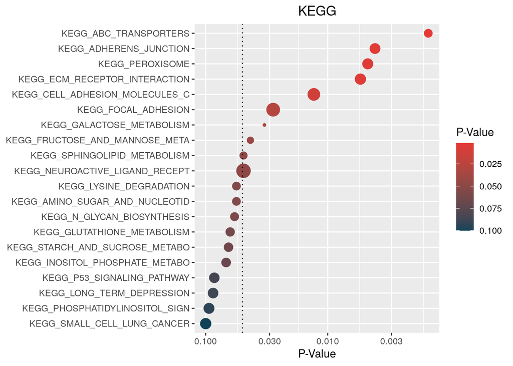

```r
hyp_dots(hyp_1, title = "KEGG", abrv = 30, val = "pval")
```

```r
#PID
hyp_1_pid <- hypeR(x_down, PID, test="hypergeometric", background=50000, pval=0.5, plotting=TRUE)
print(hyp_1_pid)
```

```
## (hyp)
##
##   data:
##                      label   pval  fdr signature geneset overlap background
##     PID_SYNDECAN_1_PATHWAY 0.0017 0.33        65      46       2      50000
##      PID_INTEGRIN1_PATHWAY 0.0034 0.33        65      66       2      50000
##      PID_INTEGRIN4_PATHWAY 0.0140 0.93        65      11       1      50000
##  PID_INTEGRIN_A9B1_PATHWAY 0.0320 0.94        65      25       1      50000
##        PID_RXR_VDR_PATHWAY 0.0330 0.94        65      26       1      50000
##         PID_NECTIN_PATHWAY 0.0380 0.94        65      30       1      50000
##           hits
##  COL11A2,LAMA5
##  COL11A2,LAMA5
##          LAMA5
##           PAOX
##          ABCA1
##        NECTIN1
##
##   plots: 16 Figures
##
##   args: signature
##         genesets
##         test
##         background
##         power
##         absolute
##         pval
##         fdr
##         plotting
##         quiet
```

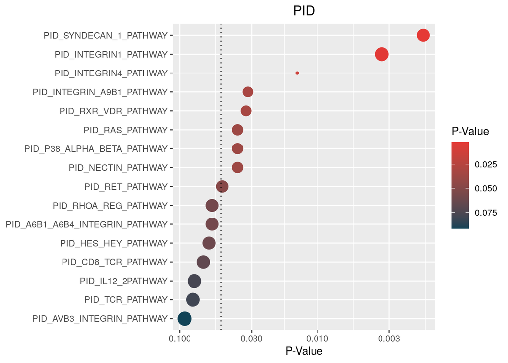

```r
hyp_dots(hyp_1_pid, title = "PID", abrv = 30, val = "pval")
```

```r
# GOBP
hyp_1_G <- hypeR(x_down, GOBP, test="hypergeometric", background=50000, fdr=0.05, plotting=TRUE)
print(hyp_1_G)
```

```
## (hyp)
##
##   data:
##                                                  label    pval     fdr
##                           GOBP_TRANSMEMBRANE_TRANSPORT 8.4e-09 6.4e-05
##                                     GOBP_ION_TRANSPORT 8.9e-08 3.4e-04
##                                GOBP_CELL_MORPHOGENESIS 6.7e-07 1.4e-03
##                        GOBP_ANIMAL_ORGAN_MORPHOGENESIS 9.0e-07 1.4e-03
##                                GOBP_TISSUE_DEVELOPMENT 9.4e-07 1.4e-03
##  GOBP_REGULATION_OF_ANATOMICAL_STRUCTURE_MORPHOGENESIS 4.8e-06 6.1e-03
##  signature geneset overlap background
##         65    1529      14      50000
##         65    1556      13      50000
##         65    1004      10      50000
##         65    1037      10      50000
##         65    1916      13      50000
##         65     976       9      50000
##                                                                                              hits
##  ABCA1,ABCC3,ANO8,GRIA3,PEX6,SESN2,SHANK3,SLC16A13,SLC22A23,SLC22A6,SLC46A1,SLC5A10,STIM1,TMEM175
##     ABCC3,ANO8,GRIA3,MELTF,NECTIN1,SHANK3,SLC16A13,SLC22A23,SLC22A6,SLC46A1,SLC5A10,STIM1,TMEM175
##                                   ATRNL1,COCH,DAB2IP,LAMA5,MEGF8,MELTF,NECTIN1,PLOD3,SHANK3,WASF3
##                                      ATRNL1,GAA,GATA5,GLG1,LAMA5,MEGF8,NECTIN1,PLOD3,SHANK3,STIM1
##                 ATRNL1,COL11A2,DAB2IP,FAM83H,GAA,GATA5,GLG1,LAMA5,MEGF8,NECTIN1,PLOD3,PRKD2,STIM1
##                                            COCH,DAB2IP,GATA5,MEGF8,MELTF,PRKD2,SHANK3,STIM1,WASF3
##
##   plots: 21 Figures
##
##   args: signature
##         genesets
##         test
##         background
##         power
##         absolute
##         pval
##         fdr
##         plotting
##         quiet
```

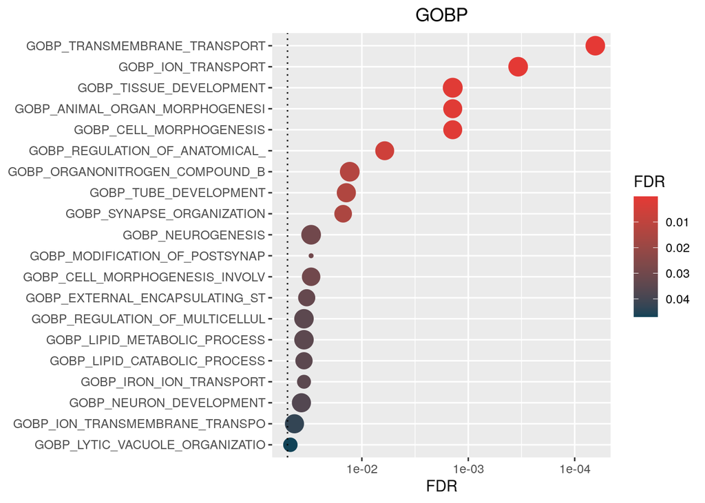

```r
hyp_dots(hyp_1_G, title="GOBP", abrv=30, val = "fdr")
```

```r
#reactome
hyp_1 <- hypeR(x_down, react, test="hypergeometric", background=50000, pval=0.5, plotting=TRUE)
print(hyp_1)
```

```
## (hyp)
##
##   data:
##                                                 label    pval  fdr signature
##  REACTOME_COLLAGEN_BIOSYNTHESIS_AND_MODIFYING_ENZYMES 9.5e-05 0.12        65
##                           REACTOME_COLLAGEN_FORMATION 2.3e-04 0.12        65
##                      REACTOME_SPHINGOLIPID_METABOLISM 2.3e-04 0.12        65
##                 REACTOME_TRANSPORT_OF_SMALL_MOLECULES 3.7e-04 0.13        65
##                         REACTOME_METABOLISM_OF_LIPIDS 4.1e-04 0.13        65
##            REACTOME_EXTRACELLULAR_MATRIX_ORGANIZATION 6.5e-04 0.16        65
##  geneset overlap background                                     hits
##       67       3      50000                     COL11A2,COL6A5,PLOD3
##       90       3      50000                     COL11A2,COL6A5,PLOD3
##       90       3      50000                        CERS2,PRKD2,SMPD4
##      728       6      50000 ABCA1,ABCC3,ANO8,SLC22A6,SLC46A1,SLC5A10
##      743       6      50000    ABCA1,ABCC3,CERS2,PRKD2,SMPD4,TSPOAP1
##      301       4      50000               COL11A2,COL6A5,LAMA5,PLOD3
##
##   plots: 171 Figures
##
##   args: signature
##         genesets
##         test
##         background
##         power
##         absolute
##         pval
##         fdr
##         plotting
##         quiet
```

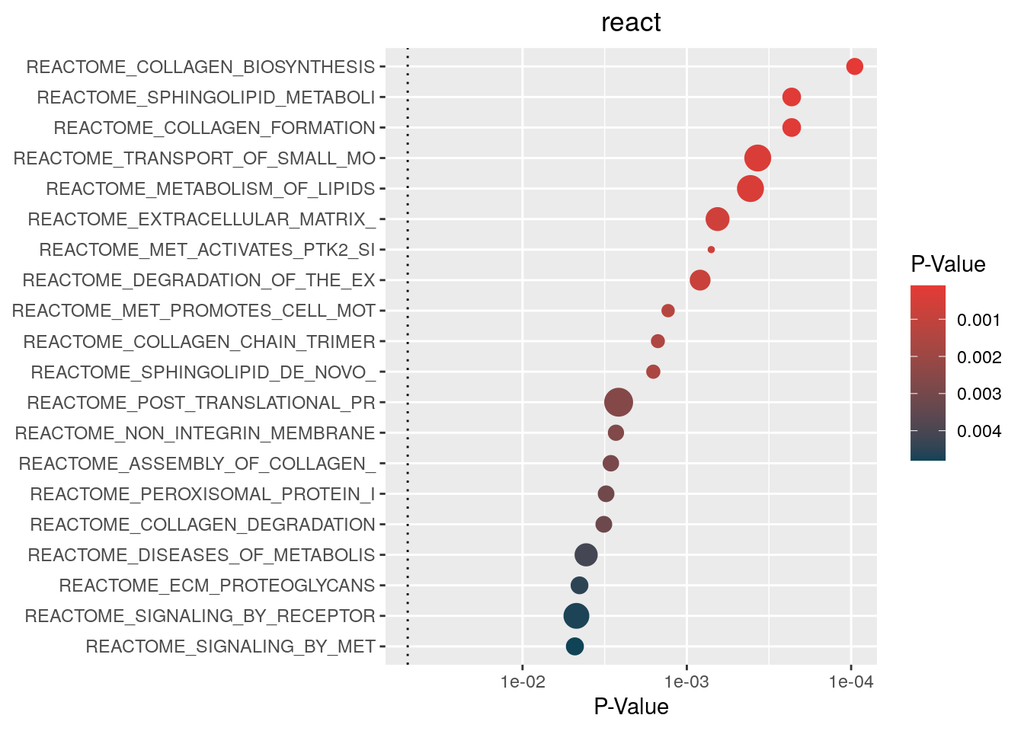

```r
hyp_dots(hyp_1, title = "react", abrv = 30, val = "pval")
```

```r
#HPO
hyp_1_hall <- hypeR(x_down, HALL, test="hypergeometric", background=50000, pval=0.5, plotting=TRUE)
print(hyp_1_hall)
```

```
## (hyp)
##
##   data:
##                           label    pval   fdr signature geneset overlap
##   HALLMARK_BILE_ACID_METABOLISM 0.00043 0.022        65     112       3
##  HALLMARK_XENOBIOTIC_METABOLISM 0.02800 0.600        65     200       2
##      HALLMARK_PROTEIN_SECRETION 0.12000 0.600        65      96       1
##             HALLMARK_PEROXISOME 0.13000 0.600        65     104       1
##             HALLMARK_DNA_REPAIR 0.18000 0.600        65     150       1
##         HALLMARK_UV_RESPONSE_UP 0.19000 0.600        65     158       1
##  background            hits
##       50000 ABCA1,PAOX,PEX6
##       50000      ABCC3,PMM1
##       50000           ABCA1
##       50000            PEX6
##       50000            NPR2
##       50000         SELENOW
##
##   plots: 19 Figures
##
##   args: signature
##         genesets
##         test
##         background
##         power
##         absolute
##         pval
##         fdr
##         plotting
##         quiet
```

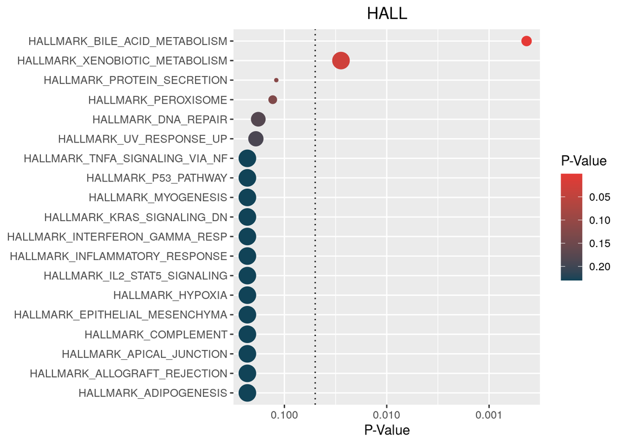

```r
hyp_dots(hyp_1_hall, title = "HALL", abrv = 30, val = "pval")
```

## Box Plots

### Data input

Load in externally made csv file with genes of interest to be plotted.

```r
top_deg <- read.csv("boxplot_DEG.csv", header = T)
head(top_deg)
```

```
##    gene_id SRR7811754 SRR7811767 SRR7811766 SRR7811762 SRR7811764 SRR7811759
## 1     CISH  858.00327  329.63399  632.09989  385.40127  483.83595 2818.29622
## 2  SLCO1C1   64.00241   20.06468   93.80988   45.28465   83.07160  347.49866
## 3 SERPINC1  163.25251   88.85786  221.12328   96.35032  245.84704 1374.48945
## 4    NDST3  129.85995   40.12936  214.42258   72.26274   42.65839  477.92467
## 5   PLCXD2  249.51663  119.43261  148.53231  146.45248  108.89115   50.16385
## 6  RTN4RL2  166.03523  358.29782  217.77293  321.81006  301.97650   74.78974
##   SRR7811758 SRR7811765 SRR7811757 SRR7811750
## 1 1761.13672 2029.35569 1871.78676 3020.44305
## 2  298.03852  740.22722  317.32230  198.29169
## 3  636.21691 1294.70107  688.56865  222.32704
## 4  308.07349  463.45469  219.84421  257.37860
## 5   81.28323   15.78904   64.29406   71.10459
## 6  108.37764   78.94519  132.73613  129.19004
```

Load in annotation file

```r
meta <- read.csv("boxplot_meta.csv", header = T)
head(meta)
```

```
##       sample condition replicate
## 1 SRR7811754      fall         1
## 2 SRR7811767      fall         2
## 3 SRR7811766      fall         3
## 4 SRR7811762      fall         4
## 5 SRR7811764      fall         5
## 6 SRR7811759    spring         1
```

Gather normalized counts of each sample.

```r
expression_plot <- pivot_longer(top_deg,
                                cols = 2:11,
                                names_to = "sample",
                                values_to = "normalized_counts")

#View(expression_plot)
```

Merge ‘expression_plot’ with ‘metadata’ dataframe.

```r
# Join metadata for visualizing groups or features
expression_plot <- left_join(x = expression_plot,
                             y = meta,
                             by = "sample")
expression_plot <-
  expression_plot %>%
  dplyr::select(gene_id, sample, normalized_counts, condition)

#View(expression_plot)
```

Genes to be visualized: - Common strongly upregulated genes: CISH, SLCO1C1, NDST3 - Additional upregulated gene from this analysis: SERPINC1 - Most upregulated gene: SLCO1C1 : CISH (orig.) - Most downregulated gene: PLCXD2 : RTN4RL2 (orig.) - Genes involved in several pathways - up: AGXT, CTH - down: NECTIN1, ATRNL1, PLOD3, NPR2

First, objects created based on all of the genes to be visualized. Then, from objects condtion was selected and seasons were releveled. Boxplots were created by plotting condition against normalized counts with added aesthetic features.

```r
# CISH
CISH_exp <- expression_plot %>%
filter(gene_id == "CISH")

#View(CISH_exp)

CISH_exp$condition <- factor(CISH_exp$condition, levels = c("fall", "spring"))

boxplot_CISH <- ggplot(CISH_exp) +
  geom_boxplot(aes(x=condition,
                   y=normalized_counts,
                   fill=condition)) +
  theme_bw() + scale_fill_manual(values = c("darkgreen", "darkorchid")) +
        ggtitle("CISH") +
        xlab("Condition") +
        ylab("Normalized Counts") +
        theme(legend.position = "right",
              panel.grid = element_blank(),
              plot.title = element_text(size = rel(1.25), hjust = 0.5), #title
              axis.title = element_text(size = rel(0.75)),
              axis.text = element_text(size = rel(0.75))) #axis
```

```r
# SLCO1C1
SLCO1C1_exp <- expression_plot %>%
filter(gene_id == "SLCO1C1")

#View(SLCO1C1_exp)

SLCO1C1_exp$condition <- factor(SLCO1C1_exp$condition, levels = c("fall", "spring"))

boxplot_SLCO1C1 <- ggplot(SLCO1C1_exp) +
  geom_boxplot(aes(x=condition,
                   y=normalized_counts,
                   fill=condition)) +
  theme_bw() + scale_fill_manual(values = c("darkgreen", "darkorchid")) +
        ggtitle("SLCO1C1") +
        xlab("Condition") +
        ylab("Normalized Counts") +
        theme(legend.position = "right",
              panel.grid = element_blank(),
              plot.title = element_text(size = rel(1.25), hjust = 0.5), #title
              axis.title = element_text(size = rel(0.75)),
              axis.text = element_text(size = rel(0.75))) #axis
```

```r
# SERPINC1
SERPINC1_exp <- expression_plot %>%
filter(gene_id == "SERPINC1")

#View(SERPINC1_exp)

SERPINC1_exp$condition <- factor(SERPINC1_exp$condition, levels = c("fall", "spring"))

boxplot_SERPINC1 <- ggplot(SERPINC1_exp) +
  geom_boxplot(aes(x=condition,
                   y=normalized_counts,
                   fill=condition)) +
  theme_bw() + scale_fill_manual(values = c("darkgreen", "darkorchid")) +
        ggtitle("SERPINC1") +
        xlab("Condition") +
        ylab("Normalized Counts") +
        theme(legend.position = "right",
              panel.grid = element_blank(),
              plot.title = element_text(size = rel(1.25), hjust = 0.5), #title
              axis.title = element_text(size = rel(0.75)),
              axis.text = element_text(size = rel(0.75))) #axis
```

```r
# NDST3
NDST3_exp <- expression_plot %>%
filter(gene_id == "NDST3")

#View(NDST3_exp)

NDST3_exp$condition <- factor(NDST3_exp$condition, levels = c("fall", "spring"))

boxplot_NDST3 <- ggplot(NDST3_exp) +
  geom_boxplot(aes(x=condition,
                   y=normalized_counts,
                   fill=condition)) +
  theme_bw() + scale_fill_manual(values = c("darkgreen", "darkorchid")) +
        ggtitle("NDST3") +
        xlab("Condition") +
        ylab("Normalized Counts") +
        theme(legend.position = "right",
              panel.grid = element_blank(),
              plot.title = element_text(size = rel(1.25), hjust = 0.5), #title
              axis.title = element_text(size = rel(0.75)),
              axis.text = element_text(size = rel(0.75))) #axis
```

```r
# PLCXD2
PLCXD2_exp <- expression_plot %>%
filter(gene_id == "PLCXD2")

#View(PLCXD2_exp)

PLCXD2_exp$condition <- factor(PLCXD2_exp$condition, levels = c("fall", "spring"))

boxplot_PLCXD2 <- ggplot(PLCXD2_exp) +
  geom_boxplot(aes(x=condition,
                   y=normalized_counts,
                   fill=condition)) +
  theme_bw() + scale_fill_manual(values = c("darkgreen", "darkorchid")) +
        ggtitle("PLCXD2") +
        xlab("Condition") +
        ylab("Normalized Counts") +
        theme(legend.position = "right",
              panel.grid = element_blank(),
              plot.title = element_text(size = rel(1.25), hjust = 0.5), #title
              axis.title = element_text(size = rel(0.75)),
              axis.text = element_text(size = rel(0.75))) #axis
```

```r
# RTN4RL2
RTN4RL2_exp <- expression_plot %>%
filter(gene_id == "RTN4RL2")

#View(RTN4RL2_exp)

RTN4RL2_exp$condition <- factor(RTN4RL2_exp$condition, levels = c("fall", "spring"))

boxplot_RTN4RL2 <- ggplot(RTN4RL2_exp) +
  geom_boxplot(aes(x=condition,
                   y=normalized_counts,
                   fill=condition)) +
  theme_bw() + scale_fill_manual(values = c("darkgreen", "darkorchid")) +
        ggtitle("RTN4RL2") +
        xlab("Condition") +
        ylab("Normalized Counts") +
        theme(legend.position = "right",
              panel.grid = element_blank(),
              plot.title = element_text(size = rel(1.25), hjust = 0.5), #title
              axis.title = element_text(size = rel(0.75)),
              axis.text = element_text(size = rel(0.75))) #axis
```

```r
# AGXT
AGXT_exp <- expression_plot %>%
filter(gene_id == "AGXT")

#View(AGXT_exp)

AGXT_exp$condition <- factor(AGXT_exp$condition, levels = c("fall", "spring"))

boxplot_AGXT <- ggplot(AGXT_exp) +
  geom_boxplot(aes(x=condition,
                   y=normalized_counts,
                   fill=condition)) +
  theme_bw() + scale_fill_manual(values = c("darkgreen", "darkorchid")) +
        ggtitle("AGXT") +
        xlab("Condition") +
        ylab("Normalized Counts") +
        theme(legend.position = "right",
              panel.grid = element_blank(),
              plot.title = element_text(size = rel(1.25), hjust = 0.5), #title
              axis.title = element_text(size = rel(0.75)),
              axis.text = element_text(size = rel(0.75))) #axis
```

```r
# CTH
CTH_exp <- expression_plot %>%
filter(gene_id == "CTH")

#View(CTH_exp)

CTH_exp$condition <- factor(CTH_exp$condition, levels = c("fall", "spring"))

boxplot_CTH <- ggplot(CTH_exp) +
  geom_boxplot(aes(x=condition,
                   y=normalized_counts,
                   fill=condition)) +
  theme_bw() + scale_fill_manual(values = c("darkgreen", "darkorchid")) +
        ggtitle("CTH") +
        xlab("Condition") +
        ylab("Normalized Counts") +
        theme(legend.position = "right",
              panel.grid = element_blank(),
              plot.title = element_text(size = rel(1.25), hjust = 0.5), #title
              axis.title = element_text(size = rel(0.75)),
              axis.text = element_text(size = rel(0.75))) #axis
```

```r
# NECTIN1
NECTIN1_exp <- expression_plot %>%
filter(gene_id == "NECTIN1")

#View(NECTIN1_exp)

NECTIN1_exp$condition <- factor(NECTIN1_exp$condition, levels = c("fall", "spring"))

boxplot_NECTIN1 <- ggplot(NECTIN1_exp) +
  geom_boxplot(aes(x=condition,
                   y=normalized_counts,
                   fill=condition)) +
  theme_bw() + scale_fill_manual(values = c("darkgreen", "darkorchid")) +
        ggtitle("NECTIN1") +
        xlab("Condition") +
        ylab("Normalized Counts") +
        theme(legend.position = "right",
              panel.grid = element_blank(),
              plot.title = element_text(size = rel(1.25), hjust = 0.5), #title
              axis.title = element_text(size = rel(0.75)),
              axis.text = element_text(size = rel(0.75))) #axis
```

```r
# ATRNL1
ATRNL1_exp <- expression_plot %>%
filter(gene_id == "ATRNL1")

#View(ATRNL1_exp)

ATRNL1_exp$condition <- factor(ATRNL1_exp$condition, levels = c("fall", "spring"))

boxplot_ATRNL1 <- ggplot(ATRNL1_exp) +
  geom_boxplot(aes(x=condition,
                   y=normalized_counts,
                   fill=condition)) +
  theme_bw() + scale_fill_manual(values = c("darkgreen", "darkorchid")) +
        ggtitle("ATRNL1") +
        xlab("Condition") +
        ylab("Normalized Counts") +
        theme(legend.position = "right",
              panel.grid = element_blank(),
              plot.title = element_text(size = rel(1.25), hjust = 0.5), #title
              axis.title = element_text(size = rel(0.75)),
              axis.text = element_text(size = rel(0.75))) #axis
```

```r
# PLOD3
PLOD3_exp <- expression_plot %>%
filter(gene_id == "PLOD3")

#View(PLOD3_exp)

PLOD3_exp$condition <- factor(PLOD3_exp$condition, levels = c("fall", "spring"))

boxplot_PLOD3 <- ggplot(PLOD3_exp) +
  geom_boxplot(aes(x=condition,
                   y=normalized_counts,
                   fill=condition)) +
  theme_bw() + scale_fill_manual(values = c("darkgreen", "darkorchid")) +
        ggtitle("PLOD3") +
        xlab("Condition") +
        ylab("Normalized Counts") +
        theme(legend.position = "right",
              panel.grid = element_blank(),
              plot.title = element_text(size = rel(1.25), hjust = 0.5), #title
              axis.title = element_text(size = rel(0.75)),
              axis.text = element_text(size = rel(0.75))) #axis
```

```r
# NPR2
NPR2_exp <- expression_plot %>%
filter(gene_id == "NPR2")

#View(NPR2_exp)

NPR2_exp$condition <- factor(NPR2_exp$condition, levels = c("fall", "spring"))

boxplot_NPR2 <- ggplot(NPR2_exp) +
  geom_boxplot(aes(x=condition,
                   y=normalized_counts,
                   fill=condition)) +
  theme_bw() + scale_fill_manual(values = c("darkgreen", "darkorchid")) +
        ggtitle("NPR2") +
        xlab("Condition") +
        ylab("Normalized Counts") +
        theme(legend.position = "right",
              panel.grid = element_blank(),
              plot.title = element_text(size = rel(1.25), hjust = 0.5), #title
              axis.title = element_text(size = rel(0.75)),
              axis.text = element_text(size = rel(0.75))) #axis
```

Genes that want to be discussed together we grouped in a boxplot grid.

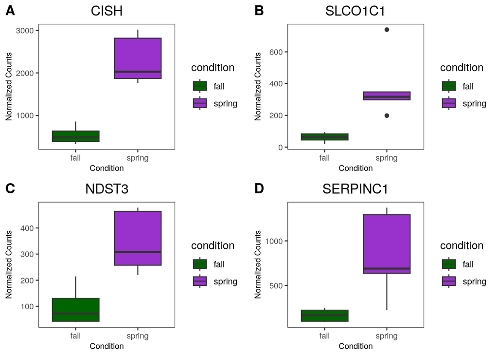

```r
# Arranging upregulated plots in a figure
boxplot_grid_upreg <- plot_grid(boxplot_CISH,
                          boxplot_SLCO1C1,
                          boxplot_NDST3,
                          boxplot_SERPINC1,
                          labels = c("A", "B", "C", "D"),
                          align = 'v',
                          ncol = 2)

boxplot_grid_upreg
```

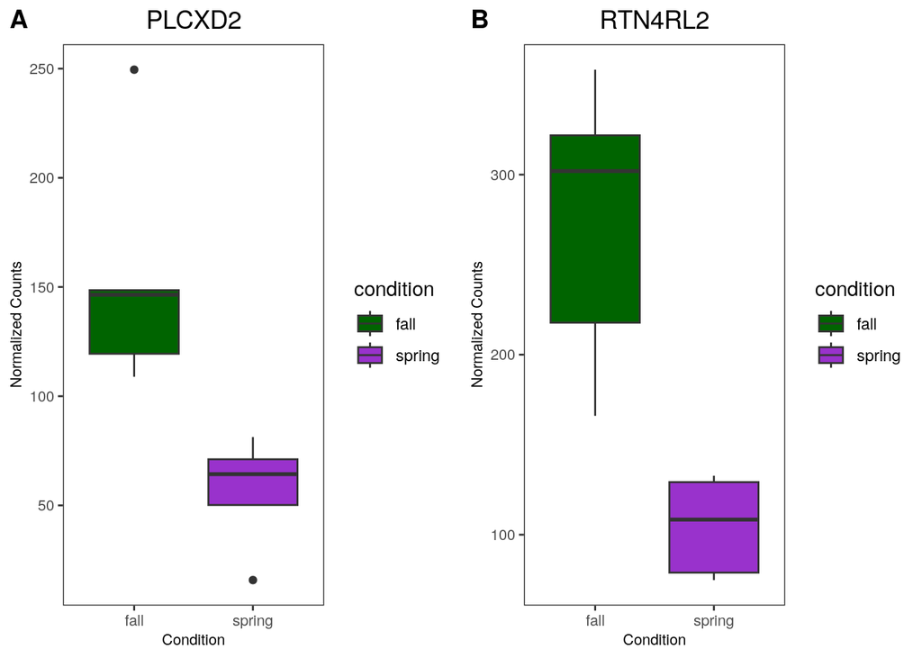

```r
# Arranging downregulated plots in a figure
boxplot_grid_downreg <- plot_grid(boxplot_PLCXD2,
                          boxplot_RTN4RL2,
                          labels = c("A", "B"),
                          align = 'v',
                          ncol = 2)

boxplot_grid_downreg
```

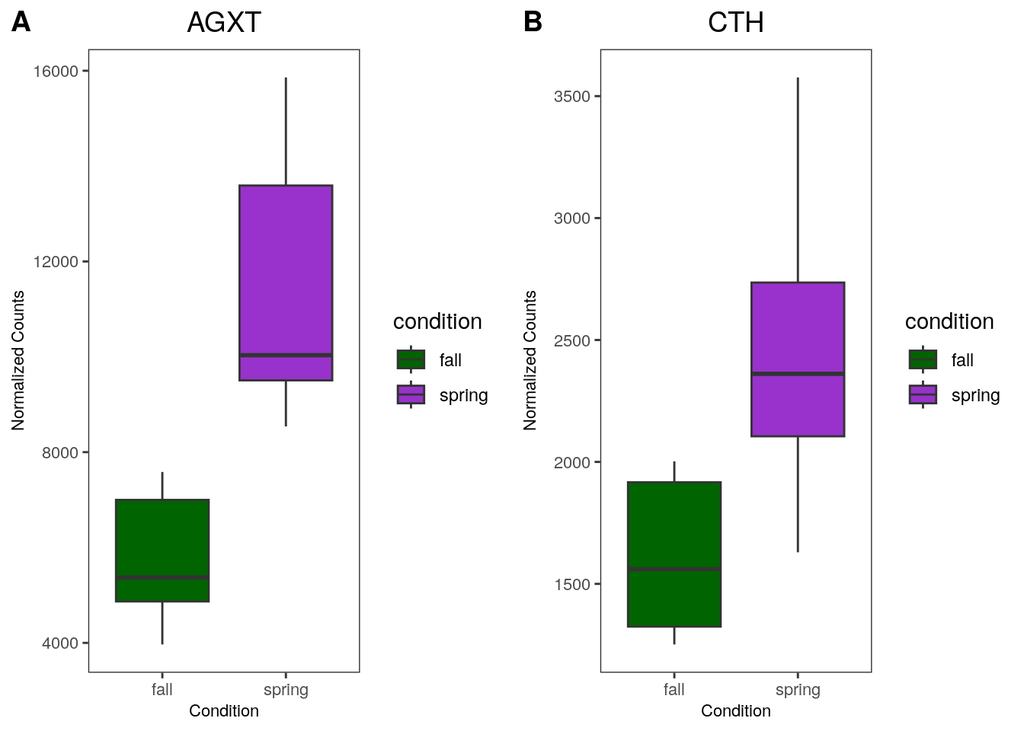

```r
# Arranging upregulated pathway gene plots in a figure
boxplot_grid_uppath <- plot_grid(boxplot_AGXT,
                          boxplot_CTH,
                          labels = c("A", "B"),
                          align = 'v',
                          ncol = 2)

boxplot_grid_uppath
```

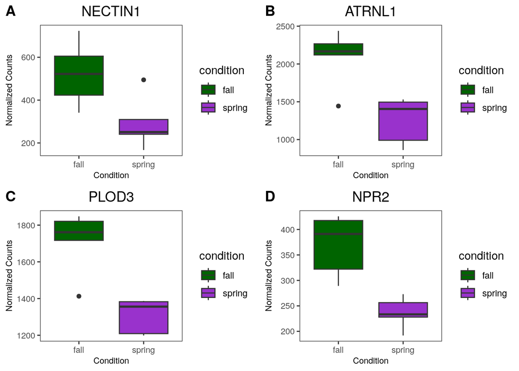

```r
# Arranging downregulated pathway gene plots in a figure
boxplot_grid_downpath <- plot_grid(boxplot_NECTIN1,
                          boxplot_ATRNL1,
                          boxplot_PLOD3,
                          boxplot_NPR2,
                          labels = c("A", "B", "C", "D"),
                          align = 'v',
                          ncol = 2)

boxplot_grid_downpath
```

Save boxplot grids to pdf

```r
# Save upregulated plots to pdf
ggsave(plot = boxplot_grid_upreg,
       filename = "boxplot_figure_upreg.pdf",
       device = "pdf",
       width = 6,
       height = 4,
       units = "in",
       dpi = 300)

# Save downregulated plots to pdf
ggsave(plot = boxplot_grid_downreg,
       filename = "boxplot_figure_downreg.pdf",
       device = "pdf",
       width = 6,
       height = 4,
       units = "in",
       dpi = 300)

# Save upregulated pathway plots to pdf
ggsave(plot = boxplot_grid_uppath,
       filename = "boxplot_figure_uppath.pdf",
       device = "pdf",
       width = 6,
       height = 4,
       units = "in",
       dpi = 300)

# Save downregulated pathway plots to pdf
ggsave(plot = boxplot_grid_downpath,
       filename = "boxplot_figure_downpath.pdf",
       device = "pdf",
       width = 6,
       height = 4,
       units = "in",
       dpi = 300)
```